# Switching from Matlab to Python

by Nick Cortale

This guide will hopefully ease the transition from Matlab to python. Most of this guide was taken from Jake Vanderplas's guide at:

http://www.astro.washington.edu/users/vanderplas/Astr599/notebooks/

I strongly suggest checking out all his notebooks. They are full of great information. This guide is to be more of a short introduction and hopeully make the transition less daunting.

The main difference between python and matlab is that matlab is like an all inclusive resort. Matlab provides everything that is needed in a complete, polished package. Very few headaches, but there is little interaction with things that are outside of the "matlab area". Things like interfacing with the web are signficantly easier with python.

Python is more like backpacking through Europe (or I would imagine). Many people have done it before and created well documented routes and adventures that work well. You also might get lost on the way and have to create your own path. You also learn a lot on the way. This is why, in my opinion, the python community is so welcoming. They've all been on the same journey.

**Downloads**

The first thing you will need to do is download the anaconda package manager. This installs everything you will need in the scientific stack --or mostly everything. This can be thought of as installing all the matlab toolboxes. This download will also include the jupyter notebook, which is what this is written in. The download can be found here:

Anaconda : https://store.continuum.io/cshop/anaconda/

The next thing you will want to download is a text editor. This is where you will write your functions, classes, and anything else you could want. I like sublime text, but there are others out there that you can experiment with.

Text Editor: http://www.sublimetext.com/

**Education**

There are a ton of resources out there for those switching over from Matlab to python. The documentation for python packages is great. There are tons of examples and explanations about everything you could want. If you feel like the documentation isn't working out for you, simply googling something like "linspace in python" or "xlim in python" will usually get you what you need. Here are some resources to get you started.

Python for Matlab Users: http://mathesaurus.sourceforge.net/matlab-numpy.html

Scipy 2014 : https://www.youtube.com/playlist?list=PLYx7XA2nY5GfuhCvStxgbynFNrxr3VFog

**Packages**

There are two core packages --you can think of them like toolboxes --that reproduce most of the core matlab package. They are matplotlib, which is a plotting environment, and numpy, which is a matrix multiplication library and much more. Some other interesting packages are Scikit Learn for machine learning and Pandas for manipulating data.

Matplotlib : http://matplotlib.org/

Numpy : http://www.numpy.org/

Scikit Learn: http://scikit-learn.org/stable/

Pandas : http://pandas.pydata.org/

Alright. Lets get into it!

# Comparing some code

### Matlab:

```
%some matlab code
x = linspace(0,2*pi);
y = sin(x);
plot(x,y)
```

### Python:

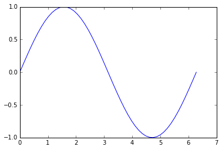

```python
#Some python code
import matplotlib.pyplot as plt
import numpy as np
%matplotlib inline

x = np.linspace(0,2*np.pi)
y = np.sin(x)

plt.plot(x,y)
```

Okay, so the first obvious difference is the **import** at the top of the code. Since python has such a huge opensource ecosystem, we have to tell python which packages we wish to utilize. The "matplotlib.pyplot" is our plotting library. and the "%matplotlib inline" is called a magic. Don't worry about it too much. It allows us to have "inline plots".

Also notice the "np." before linspace, pi, and sin. This tells python that we want to use the numpy versions of those functions. For example, there are other implentations of "min" and "max" in numpy than in base python. The same thing goes for "plt.".

# Part 1

Here we are just going to get our feet wet in some basic python and see how it differs from matlab.

## 1. Print Hello World / Print Variables

## 2. Integers vs Floats

## 3. Indentation Matters

## 4. Comparisons of Strings/Numbers

## 5. Flow Control: Conditionals and Loops

## 1. Print Hello World / Print Variables

```python
print "Hello World!"
```

```
Hello World!
```

```python
a = 4
b = 6
c = a/b
```

```python
print 'a =', a
print 'b =', b
print 'c =', c
```

```
a = 4
b = 6
c = 0
```

## 2. Integers vs Floats

Python treats 4 and 4.0 differently. One 4.0 is a float and 4 is an integer. If you downloaded python 3, the default behavior is just like matlab.

```python
a = 4
b = 6
c = a/b
print c
```

```
0
```

```python
d = 4.
e = 6.
f = d/e**2
print f
```

```
0.111111111111
```

```python
a+=8  # same as: a = a+8
print a
```

```
12
```

## 3. Indentation Matters

Unlike Matlab, python cares about white space. Instead of having "ends" after for-loops, python uses white space. This means that you have to be careful when coding to adhere to python's syntax. This counts for both spaces and tabs.

```python
# tab
a = 4.
    b = 6
```

```
  File "<ipython-input-8-40875328fc1a>", line 3
    b = 6
    ^
IndentationError: unexpected indent
```

```python
# space
a = 4.
 b = 6.
```

```
  File "<ipython-input-9-4a8a36d0ff7b>", line 3
    b = 6.
    ^
IndentationError: unexpected indent
```

## 4. Comparisons of Strings and Numbers

This is the same in matlab as it is in python.

```python
a == b
```

```
False
```

```python
a != b
```

```
True
```

```python
a == b-2
```

```
False
```

```python
c = np.linspace(1,10,num=10)
c
```

```
array([  1.,   2.,   3.,   4.,   5.,   6.,   7.,   8.,   9.,  10.])
```

```python
print c
```

```
[  1.   2.   3.   4.   5.   6.   7.   8.   9.  10.]
```

```python
c == c
```

```
array([ True,  True,  True,  True,  True,  True,  True,  True,  True,  True], dtype=bool)
```

```python
False
```

```
False
```

```python
True
```

```
True
```

```python
not False
```

```
True
```

```python
False == False
```

```
True
```

### Be careful with floating points

Due to differences in absolute accuracy, the two wont be the same. For example it might be 0.30000002032 == 0.30000000392 or something.

```python
(.1 + .2) == .3
```

```
False
```

## 5. Flow Control: Conditionals and Loops

Again, white space is very important here. Instead of using "ends", python utilizes indents.

```python
x = 1
if x > 0:
    print "yo"
else:
    print "dude"
```

```
yo
```

```python
# Could also do this with a break statement
x = 1
y = 0
while True:
    print "yo" if x > 0 else "dude"
    x *= -1
    y += 1
    if y >= 10:
        break
```

```
yo
dude
yo
dude
yo
dude
yo
dude
yo
dude
```

```python
if x < 1:
    print "t"
elif x > 100:
    print "yo"
elif x == 42:
    print "bingo"
else:
    print "dude"
```

```
dude
```

## 6. Functions

Functions work differently in python than in matlab. You can put a bunch of small ones at the top of your script or dispersed through out. Again, watch your whitespace.

```python
def addnums(x, y):
    return x + y
```

```python
result = addnums(1, 2)
print result
```

```
3
```

### With Keywords

Keywords are a useful part of functions. They allow you to have a defualt value most of the time, but if you want to change it, you can.

```python
def scale(x, factor=2.0):
    return x * factor
```

```python
scale(4)
```

```
8.0
```

```python
scale(4, factor=10)
```

```
40
```

### Functions have own variables

It doesn't matter what is in your workspace. A function is self-contained. The same as Matlab.

```python
def modify_x(x):
    x += 5
    return x
```

```python
x = 10
y = modify_x(x)

print x
print y
```

```
10
15
```

### Modules

You might have a bunch of useful functions that you want to import and use within your script, but don't want them to be in the same script. No worries! You can simply import them as long as they are in the same working directory.

```python
%%file mymodule.py

# this is another magic function that creates a
# file from everything else in the cell
# A simple demonstration module

def add_numbers(x, y):
    """add x and y"""
    return x + y

def subtract_numbers(x, y):
    """subtract y from x"""
    return x - y
```

```
Overwriting mymodule.py
```

```python
ls
```

```
forgetting_mathworks.ipynb  mymodule.pyc
mymodule.py
```

```python
import mymodule as MM
```

```python
print '1 + 2 =', MM.add_numbers(1, 2)
print '5 - 3 =', MM.subtract_numbers(5, 3)
```

```
1 + 2 = 3
5 - 3 = 2
```

## Whos

Whos command is very useful in matlab and there is a built-in version of that here. It's another magic.

```python
%whos
```

```
Variable   Type        Data/Info
--------------------------------
MM         module      <module 'mymodule' from 'mymodule.py'>
a          int         12
addnums    function    <function addnums at 0x106074a28>
b          int         6
c          ndarray     10: 10 elems, type `float64`, 80 bytes
d          float       4.0
e          float       6.0
f          float       0.111111111111
modify_x   function    <function modify_x at 0x106074668>
np         module      <module 'numpy' from '//a<...>ages/numpy/__init__.pyc'>
plt        module      <module 'matplotlib.pyplo<...>s/matplotlib/pyplot.pyc'>
result     int         3
scale      function    <function scale at 0x106074398>
x          int         10
y          int         15
```

# Part 2 : Closer to Matlab

Now that we have some of the syntax down, we can move onto numpy and matplotlib. You should feel more at home here as these two packages are extremely similar to matlab syntax except for a few python quirks.

# 1. Numpy

# 2. Matplotlib

# 1. Numpy

Numpy is going to be used for the majority of your processes. Most of these functions should seem familiar.

```python
import numpy as np
```

```python
x = np.zeros(5)
x
```

```
array([ 0.,  0.,  0.,  0.,  0.])
```

```python
x2 = np.ones(x.shape)
x2
```

```
array([ 1.,  1.,  1.,  1.,  1.])
```

```python
#notice the tuple
y = np.zeros((5,5))
y
```

```
array([[ 0.,  0.,  0.,  0.,  0.],
       [ 0.,  0.,  0.,  0.,  0.],
       [ 0.,  0.,  0.,  0.,  0.],
       [ 0.,  0.,  0.,  0.,  0.],
       [ 0.,  0.,  0.,  0.,  0.]])
```

```python
y
```

```
array([[ 0.,  0.,  0.,  0.,  0.],
       [ 0.,  0.,  0.,  0.,  0.],
       [ 0.,  0.,  0.,  0.,  0.],
       [ 0.,  0.,  0.,  0.,  0.],
       [ 0.,  0.,  0.,  0.,  0.]])
```

```python
print x
print
print y
```

```
[ 0.  0.  0.  0.  0.]

[[ 0.  0.  0.  0.  0.]
 [ 0.  0.  0.  0.  0.]
 [ 0.  0.  0.  0.  0.]
 [ 0.  0.  0.  0.  0.]
 [ 0.  0.  0.  0.  0.]]
```

```python
x = np.linspace(1,50)
print x
```

```
[  1.   2.   3.   4.   5.   6.   7.   8.   9.  10.  11.  12.  13.  14.  15.
  16.  17.  18.  19.  20.  21.  22.  23.  24.  25.  26.  27.  28.  29.  30.
  31.  32.  33.  34.  35.  36.  37.  38.  39.  40.  41.  42.  43.  44.  45.
  46.  47.  48.  49.  50.]
```

```python
x = np.random.rand(5,5)
print x
```

```
[[ 0.49389857  0.81298705  0.80786856  0.11135069  0.66657428]
 [ 0.93251701  0.93282489  0.48220245  0.61401031  0.60531441]
 [ 0.34715848  0.91133081  0.19259777  0.94134356  0.45213768]
 [ 0.91781632  0.67160317  0.81824673  0.25184411  0.97693561]
 [ 0.9078972   0.10408555  0.24976669  0.9767883   0.36110312]]
```

## Shapes and Indexing

One of the biggest differences for me was the difference between a shape that is (5,1) and one that has a shape of (5,). These are not the same in numpy and the shape of (5,) does not even exist in matlab.

```python
x = np.random.rand(5)
y = np.random.rand(5,5)
```

```python
print x.shape
print
print y.shape
```

```
(5,)

(5, 5)
```

```python
x2 = x.reshape(5,1)
```

```python
print x.shape
print x2.shape
```

```
(5,)
(5, 1)
```

```python
print y
```

```
[[ 0.38807982  0.41793284  0.60967243  0.71864268  0.0866159 ]
 [ 0.57923627  0.12221912  0.32031761  0.43584125  0.53457958]
 [ 0.77863344  0.66037222  0.17682793  0.03808093  0.54383412]
 [ 0.03035502  0.33029575  0.82174283  0.87737263  0.56510797]
 [ 0.58939411  0.40171522  0.67835752  0.41880659  0.63741916]]
```

It is possible to create masks just like you would in matlab.

```python
mask = y>.5
mask
```

```
array([[False, False,  True,  True, False],
       [ True, False, False, False,  True],
       [ True,  True, False, False,  True],
       [False, False,  True,  True,  True],
       [ True, False,  True, False,  True]], dtype=bool)
```

```python
y[mask]
```

```
array([ 0.60967243,  0.71864268,  0.57923627,  0.53457958,  0.77863344,
        0.66037222,  0.54383412,  0.82174283,  0.87737263,  0.56510797,
        0.58939411,  0.67835752,  0.63741916])
```

## Indexing

Another huge difference is indexing. The indexing in python starts at zero for the first element. This definitely takes some getting used to, but has its advantages in the long run--or so I think it does.

```python
print y
```

```
[[ 0.38807982  0.41793284  0.60967243  0.71864268  0.0866159 ]
 [ 0.57923627  0.12221912  0.32031761  0.43584125  0.53457958]
 [ 0.77863344  0.66037222  0.17682793  0.03808093  0.54383412]
 [ 0.03035502  0.33029575  0.82174283  0.87737263  0.56510797]
 [ 0.58939411  0.40171522  0.67835752  0.41880659  0.63741916]]
```

```python
y[0,0]
```

```
0.38807981759720556
```

```python
y[0:2,0:2]
```

```
array([[ 0.38807982,  0.41793284],
       [ 0.57923627,  0.12221912]])
```

```python
y[1]
```

```
array([ 0.57923627,  0.12221912,  0.32031761,  0.43584125,  0.53457958])
```

```python
y[:,1]
```

```
array([ 0.41793284,  0.12221912,  0.66037222,  0.33029575,  0.40171522])
```

## Views are not copies

Matlab creates copies of everything and this makes it sometimes very inefficient. Python creates a view into an array. This means that it is not an actual copy, but just a pointer to the other array. This is a little confusing until you see it in action

```python
x = np.arange(8)
x_2 = x.reshape(2, 4)


print x
print
print x_2
```

```
[0 1 2 3 4 5 6 7]

[[0 1 2 3]
 [4 5 6 7]]
```

```python
x[0] = 1000
print x
print
print x_2
```

```
[1000    1    2    3    4    5    6    7]

[[1000    1    2    3]
 [   4    5    6    7]]
```

We can see that although we only modified x, x_2 was also changed

## Properties and Methods

Instead of calling a function, you can use dot notation to get information about a matrix or perform some basic operations.

```python
print 'Data type                :', x.dtype
print 'Total number of elements :', x.size
print 'Number of dimensions     :', x.ndim
print 'Shape (dimensionality)   :', x.shape
print 'Memory used (in bytes)   :', x.nbytes
```

```
Data type                : int64
Total number of elements : 8
Number of dimensions     : 1
Shape (dimensionality)   : (8,)
Memory used (in bytes)   : 64
```

```python
print 'Minimum and maximum             :', x.min(), x.max()
print 'Sum and product of all elements :', x.sum(), x.prod()
print 'Mean and standard deviation     :', x.mean(), x.std()
```

```
Minimum and maximum             : 1 1000
Sum and product of all elements : 1028 5040000
Mean and standard deviation     : 128.5 329.401350938
```

## Matrix Operations

Most of these are the same as Matlab. The only difference is that matrix multiplication is element by element.

```python
a = np.around(np.random.rand(5,5)*10)
print a
```

```
[[  9.   9.   4.   8.   6.]
 [  9.   4.   5.   3.   7.]
 [  2.   8.   5.   3.  10.]
 [  8.   4.   0.   3.   7.]
 [  2.   9.   5.   2.   4.]]
```

```python
a*a
```

```
array([[  81.,   81.,   16.,   64.,   36.],
       [  81.,   16.,   25.,    9.,   49.],
       [   4.,   64.,   25.,    9.,  100.],
       [  64.,   16.,    0.,    9.,   49.],
       [   4.,   81.,   25.,    4.,   16.]])
```

```python
np.dot(a,a)
```

```
array([[ 246.,  235.,  131.,  147.,  237.],
       [ 165.,  212.,  116.,  122.,  181.],
       [ 144.,  192.,  123.,   84.,  179.],
       [ 146.,  163.,   87.,   99.,  125.],
       [ 133.,  138.,   98.,   72.,  155.]])
```

```python
a.T
```

```
array([[  9.,   9.,   2.,   8.,   2.],
       [  9.,   4.,   8.,   4.,   9.],
       [  4.,   5.,   5.,   0.,   5.],
       [  8.,   3.,   3.,   3.,   2.],
       [  6.,   7.,  10.,   7.,   4.]])
```

```python
a**2
```

```
array([[  81.,   81.,   16.,   64.,   36.],
       [  81.,   16.,   25.,    9.,   49.],
       [   4.,   64.,   25.,    9.,  100.],
       [  64.,   16.,    0.,    9.,   49.],
       [   4.,   81.,   25.,    4.,   16.]])
```

## Broadcasting

This is what Matlab's bsxfun does. Numpy just does it by default.

```python
b = np.arange(0,5)
print a
print
print b
```

```
[[  9.   9.   4.   8.   6.]
 [  9.   4.   5.   3.   7.]
 [  2.   8.   5.   3.  10.]
 [  8.   4.   0.   3.   7.]
 [  2.   9.   5.   2.   4.]]

[0 1 2 3 4]
```

```python
a+b
```

```
array([[  9.,  10.,   6.,  11.,  10.],
       [  9.,   5.,   7.,   6.,  11.],
       [  2.,   9.,   7.,   6.,  14.],
       [  8.,   5.,   2.,   6.,  11.],
       [  2.,  10.,   7.,   5.,   8.]])
```

### Visual example

[figure not shown]

# 2. Matplotlib

Most of the syntax for plotting is very similar to matlab.

```python
%matplotlib inline
import matplotlib.pyplot as plt
```

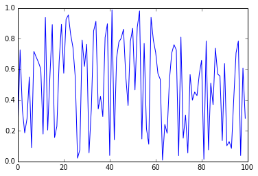

```python
plt.plot(np.random.rand(100));
```

Here's a longer example with most of the stuff that you could want to do to a plot.

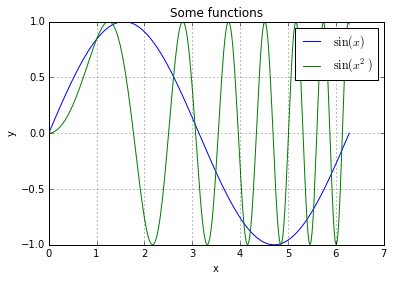

```python
x = np.linspace(0, 2*np.pi, 300)
y = np.sin(x)
y2 = np.sin(x**2)
plt.plot(x, y, label=r'$\sin(x)$')
plt.plot(x, y2, label=r'$\sin(x^2)$')
plt.title('Some functions')
plt.xlabel('x')
plt.ylabel('y')
plt.grid()
plt.legend();
```

### Figuresize and linewidth

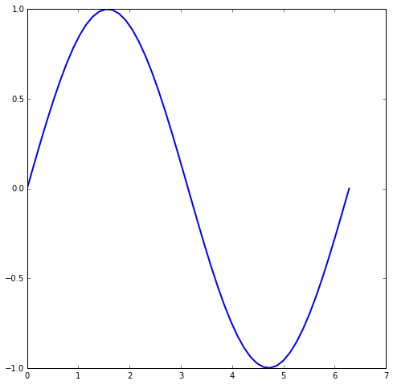

```python
plt.figure(figsize=(8,8))
x = np.linspace(0, 2*np.pi, 50)
y = np.sin(x)
plt.plot(x, y, linewidth=2);
```

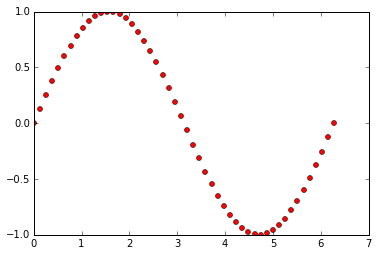

```python
plt.plot(x, y, 'o', markersize=5, color='r');
```

## 2d Arrays

```python
a = np.random.rand(20,20)
```

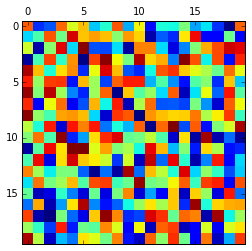

```python
plt.matshow(a)
```

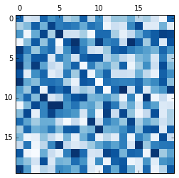

```python
plt.matshow(a,cmap='Blues')
```

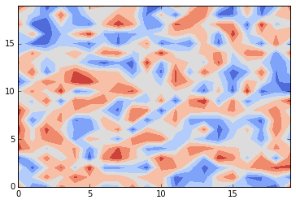

```python
plt.contourf(a,cmap='coolwarm')
```

Subplots are a little confusing to understand, but what is happening is that you are creating four axis and the plotting something on each of them.

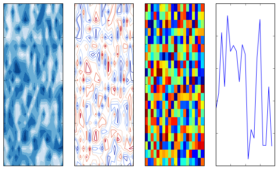

```python
fig, ax = plt.subplots(1,4, figsize=(10,6))
ax[0].contourf(a, cmap='Blues')
ax[1].contour(a, cmap='coolwarm')
ax[2].pcolor(a, cmap='jet')
ax[3].plot(a[1]);
for a in ax:
    a.set_xticklabels([])
    a.set_yticklabels([])
```

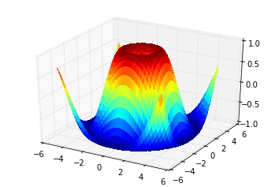

```python
from mpl_toolkits.mplot3d.axes3d import Axes3D
from matplotlib import cm

fig = plt.figure()
ax = fig.add_subplot(1, 1, 1, projection='3d')
X = np.arange(-5, 5, 0.25)
Y = np.arange(-5, 5, 0.25)
X, Y = np.meshgrid(X, Y)
R = np.sqrt(X**2 + Y**2)
Z = np.sin(R)
surf = ax.plot_surface(X, Y, Z, rstride=1, cstride=1, cmap=cm.jet,
        linewidth=0, antialiased=False)
ax.set_zlim3d(-1.01, 1.01);
```

# Seaborn

Seaborn is another python packages that takes your plots from zero to hero. It is worth reading the documentation and understanding what you can do. It is extremely simple and all you need to do is write one single line of code.

```python
a = np.random.rand(20,5)
```

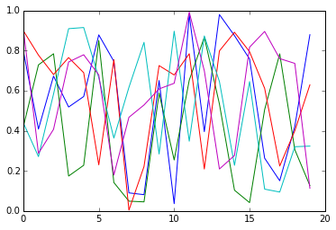

```python
#without seaborn
plt.plot(a);
```

```python
import seaborn as sns
sns.set()
```

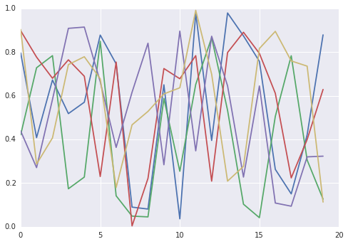

```python
plt.plot(a);
```

It's a little more stylish and I think it looks pretty great and it took almost zero effort.

# Conclusion

Well that is pretty much it. I hope switching to python is a little less daunting.

Feel free to contact me with questions, suggestions, or something you would like me to add!